# Wrangling data to write a blog post on DMM Eikaiwa teachers

In this notebook, I will wrangle the teacher dataset of DMM teachers.

# Import database files I scraped in another ipynb.

```python
import pandas as pd
import numpy as np
import sqlite3
import matplotlib
import matplotlib.pyplot as plt
import seaborn as sns
import requests
from bs4 import BeautifulSoup

pd.set_option('display.max_columns', 500)
%matplotlib inline

font = {'family': 'AppleGothic'}
matplotlib.rc('font', **font)
```

```python
# just check dataframe without duplicates is in "database2.db"
conn = sqlite3.connect("reviews2.db")

# load reviews data
reviews = pd.read_sql("SELECT * FROM reviews",conn)
print(reviews.shape)
reviews.head()
```

```
(313058, 5)
```

|  | teacher_id | name | date | rating | review |
| --- | --- | --- | --- | --- | --- |
| 0 | 398 | RIN | 2019-01-05 00:00:00 | 5.0 | 素晴らしい先生です！！ |
| 1 | 398 | MAKO | 2018-12-21 00:00:00 | 5.0 | 知的で穏やか、そしてとてもお優しく素敵な先生でした。レッスンもテキパキと進めてくださり充実し... |
| 2 | 398 | sunamin | 2018-12-18 00:00:00 | 5.0 | 定期的にJules先生のレッスン取っています。とても穏やかで優しい講師だと思います。 |
| 3 | 398 | Coco | 2018-12-11 00:00:00 | 5.0 | 話しやすく明るい素敵な先生でした。(^^♪ |
| 4 | 398 | Cindy | 2018-12-05 00:00:00 | 5.0 | 優しくて、話しやすい。発音も聞き取りやすく、生徒の目的に応じたレッスンを提供しようという思い... |

```python
# load teachers data
conn = sqlite3.connect("teachers_data.db")
teachers = pd.read_sql("SELECT * FROM profiles",conn)
```

```python
teachers.head(3)
```

|  | id | name | country | age | male | school | hobby | movie | fav | evalu | n_evalu | rate5 | rate4 | rate3 | rate2 | rate1 | message | staff_comment | 日本人講師 | ビジネス英会話 | キッズ向け | TOEFL対応 | 初心者向け | 上級者向け | スピーキングテスト対応 | Let'sGo対応 | 英検®対応 | IELTS | ネイティブ講師 | … |
| --- | --- | --- | --- | --- | --- | --- | --- | --- | --- | --- | --- | --- | --- | --- | --- | --- | --- | --- | --- | --- | --- | --- | --- | --- | --- | --- | --- | --- | --- | --- |
| 0 | 398 | Jules（ジュルズ） | イギリス | 39.0 | 0 | South East Essex College | ['Reading', ' writing', ' art and jewelry desi... | ['Bourne Trilogy'] | 4027 | 4.99 | 1745 | 1716.0 | 25.0 | 4.0 | 0.0 | 0.0 | My name is Jules and I am an English teacher f... | いつも生徒の声に耳を傾けてくれるジュルズ先生。イギリス・ロンドン出身のネイティブ講師で現在は... | 0 | 0 | 0 | 0 | 0 | 1 | 0 | 0 | 0 | 0 | 1 | … |
| 1 | 1117 | Sheri（シェリ） | フィリピン | 33.0 | 0 | University of Santo Tomas | ['reading books', ' traveling', ' eating', ' t... | ['Xmen Trilogy', ' Matrix Trilogy', ' A Beauti... | 1347 | 5.00 | 376 | 373.0 | 3.0 | 0.0 | 0.0 | 0.0 | I am Sheri and teaching is my passion. One of ... | "Teaching is my passion（教える事は情熱的なことだ）"と言い切るシェリ... | 0 | 1 | 1 | 0 | 1 | 1 | 0 | 0 | 0 | 0 | 0 | … |
| 2 | 1446 | Ella（エラ） | フィリピン | 36.0 | 0 | CAISA (Career Institute Of Southeast Asia) | ['Watching American Tv Series', ' Playing Badm... | ['A Walk to Remember'] | 2802 | 5.00 | 4395 | 4145.0 | 188.0 | 49.0 | 8.0 | 5.0 | hello everyone! My name is Shiella Mae. I pref... | 衛生コンサルタントの仕事を7年務めた経験を持つエラ先生。そのときの経験を活かして、情熱をもっ... | 0 | 1 | 0 | 0 | 0 | 0 | 0 | 0 | 0 | 0 | 0 | … |

# Preliminary Wrangling

## Statistics of data

```python
teachers.describe()
```

|  | id | age | male | fav | evalu | rate5 | rate4 | rate3 | rate2 | rate1 | 日本人講師 | ビジネス英会話 | キッズ向け | TOEFL対応 | 初心者向け | 上級者向け | スピーキングテスト対応 | Let'sGo対応 | 英検®対応 | IELTS | ネイティブ講師 | 1年未満 | 1年 | 2年 | 3年以上 |
| --- | --- | --- | --- | --- | --- | --- | --- | --- | --- | --- | --- | --- | --- | --- | --- | --- | --- | --- | --- | --- | --- | --- | --- | --- | --- |
| count | 4695.000000 | 4597.000000 | 4695.000000 | 4695.000000 | 4652.000000 | 4652.000000 | 4652.000000 | 4652.000000 | 4652.000000 | 4652.000000 | 4695.000000 | 4695.000000 | 4695.000000 | 4695.000000 | 4695.00000 | 4695.000000 | 4695.000000 | 4695.000000 | 4695.000000 | 4695.000000 | 4695.000000 | 4695.000000 | 4695.000000 | 4695.000000 | 4695.000000 |
| mean | 17687.956976 | 29.659126 | 0.292226 | 676.019595 | 4.844082 | 1141.820077 | 96.704428 | 24.049011 | 3.063199 | 3.295787 | 0.018317 | 0.185517 | 0.349521 | 0.048562 | 0.23557 | 0.426411 | 0.037700 | 0.007242 | 0.037061 | 0.027689 | 0.097764 | 0.184878 | 0.179553 | 0.148882 | 0.486688 |
| std | 8257.159381 | 7.851771 | 0.454834 | 857.971246 | 0.277039 | 1183.030417 | 109.529810 | 30.389965 | 4.933255 | 5.459867 | 0.134111 | 0.388757 | 0.476869 | 0.214974 | 0.42440 | 0.494608 | 0.190489 | 0.084799 | 0.188931 | 0.164098 | 0.297026 | 0.388240 | 0.383855 | 0.356010 | 0.499876 |
| min | 19.000000 | 0.000000 | 0.000000 | 0.000000 | 0.000000 | 0.000000 | 0.000000 | 0.000000 | 0.000000 | 0.000000 | 0.000000 | 0.000000 | 0.000000 | 0.000000 | 0.00000 | 0.000000 | 0.000000 | 0.000000 | 0.000000 | 0.000000 | 0.000000 | 0.000000 | 0.000000 | 0.000000 | 0.000000 |
| 25% | 10850.500000 | 24.000000 | 0.000000 | 123.000000 | 4.810000 | 230.000000 | 19.000000 | 5.000000 | 0.000000 | 0.000000 | 0.000000 | 0.000000 | 0.000000 | 0.000000 | 0.00000 | 0.000000 | 0.000000 | 0.000000 | 0.000000 | 0.000000 | 0.000000 | 0.000000 | 0.000000 | 0.000000 | 0.000000 |
| 50% | 19651.000000 | 28.000000 | 0.000000 | 370.000000 | 4.880000 | 722.000000 | 57.000000 | 13.000000 | 1.000000 | 1.000000 | 0.000000 | 0.000000 | 0.000000 | 0.000000 | 0.00000 | 0.000000 | 0.000000 | 0.000000 | 0.000000 | 0.000000 | 0.000000 | 0.000000 | 0.000000 | 0.000000 | 0.000000 |
| 75% | 25158.500000 | 33.000000 | 1.000000 | 884.000000 | 4.940000 | 1727.250000 | 136.000000 | 31.000000 | 4.000000 | 4.000000 | 0.000000 | 0.000000 | 1.000000 | 0.000000 | 0.00000 | 1.000000 | 0.000000 | 0.000000 | 0.000000 | 0.000000 | 0.000000 | 0.000000 | 0.000000 | 0.000000 | 1.000000 |
| max | 27788.000000 | 74.000000 | 1.000000 | 10152.000000 | 5.000000 | 9114.000000 | 840.000000 | 280.000000 | 58.000000 | 73.000000 | 1.000000 | 1.000000 | 1.000000 | 1.000000 | 1.00000 | 1.000000 | 1.000000 | 1.000000 | 1.000000 | 1.000000 | 1.000000 | 1.000000 | 1.000000 | 1.000000 | 1.000000 |

```python
reviews.describe()
```

|  | teacher_id | rating |
| --- | --- | --- |
| count | 313058.000000 | 253086.000000 |
| mean | 10789.684394 | 4.754554 |
| std | 7579.647334 | 0.744537 |
| min | 19.000000 | 1.000000 |
| 25% | 4214.000000 | 5.000000 |
| 50% | 9125.000000 | 5.000000 |
| 75% | 17135.000000 | 5.000000 |
| max | 27788.000000 | 5.000000 |

## Columns with null values

```python
# "teachers" dataframe :: columns where null values are included.
teachers.isnull().sum()[teachers.isnull().sum() != 0]
```

```
age              98
evalu            43
n_evalu          43
rate5            43
rate4            43
rate3            43
rate2            43
rate1            43
staff_comment    86
dtype: int64
```

```python
# "reviews" dataframe :: columns where null values are included.
reviews.info()
```

```
<class 'pandas.core.frame.DataFrame'>
RangeIndex: 313058 entries, 0 to 313057
Data columns (total 5 columns):
teacher_id    313058 non-null int64
name          313058 non-null object
date          313058 non-null object
rating        253086 non-null float64
review        313058 non-null object
dtypes: float64(1), int64(1), object(3)
memory usage: 11.9+ MB
```

## I will take a closer look at each of them.

### (1)age in "teachers" df

Below, I have found that most of the teachers whose age are not shown are Japanese(日本). I assume that this is because most users of DMM Eikaiwa are Japanese and that age is considered to be one of the most sensitive infomation in Japan.

Then, I took a closer look at teachers 12 other teachers and found that they are not due to the failure of scraping. I assume that these teachers were reluctant to show their age for some reasons.

### In this process, I noticed 2 things to be modified.

```python
teachers[teachers.age.isnull()].country.value_counts()
```

```
日本          86
フィリピン        9
ニュージーランド     1
アフガニスタン      1
スリナム         1
Name: country, dtype: int64
```

```python
teachers[teachers.age.isnull()][teachers[teachers.age.isnull()].country != "日本"]
```

|  | id | name | country | age | male | school | hobby | movie | fav | evalu | n_evalu | rate5 | rate4 | rate3 | rate2 | rate1 | message | staff_comment | 日本人講師 | ビジネス英会話 | キッズ向け | TOEFL対応 | 初心者向け | 上級者向け | スピーキングテスト対応 | Let'sGo対応 | 英検®対応 | IELTS | ネイティブ講師 | … |
| --- | --- | --- | --- | --- | --- | --- | --- | --- | --- | --- | --- | --- | --- | --- | --- | --- | --- | --- | --- | --- | --- | --- | --- | --- | --- | --- | --- | --- | --- | --- |
| 656 | 16472 | Rad（ラッド） | フィリピン | NaN | 1 | Our Lady of Fatima University | ['Watching documentary films', ' playing baske... | ['Enemy of The Gates'] | 510 | 4.98 | 1263 | 1219.0 | 36.0 | 8.0 | 0.0 | 0.0 | My name is Radcliffe, just call me Rad for sho... | ラッド先生は大学で看護を学びました。海外で研修を修了した先生は、マレーシアの非営利団体である... | 0 | 0 | 0 | 0 | 0 | 0 | 0 | 0 | 0 | 0 | 0 | … |
| 1516 | 17554 | Sasa DC（ササ） | フィリピン | NaN | 0 | St. Matthew College | ['Watching American TV series'] | ['50 First Dates'] | 1010 | 4.95 | 1660 | 1564.0 | 75.0 | 18.0 | 1.0 | 2.0 | My name is Sasa. I am a graduate of Bachelor o... | ササ先生は中等教育学部で英語を学びました。これまでの最大の功績は、教員免許の取得試験に合格で... | 0 | 0 | 0 | 0 | 0 | 0 | 0 | 0 | 0 | 0 | 0 | … |
| 1704 | 8570 | Czack（ザク） | フィリピン | NaN | 1 | University of Baguio | ['Surf the internet', ' Watching movies', ' go... | ['Lord of The Rings'] | 776 | 4.79 | 2844 | 2551.0 | 240.0 | 45.0 | 5.0 | 3.0 | Hello! I'm Teacher Czack. I have good communic... | SNSで知り合いの近況をチェックしたりオンラインゲームをするのが大好きという、今風の趣味を楽... | 0 | 0 | 0 | 0 | 1 | 1 | 0 | 0 | 0 | 0 | 0 | … |
| 2107 | 8046 | Marienell（マリネル） | フィリピン | NaN | 0 | University of the Visayas | ['singing and watching movies'] | ['action and suspense'] | 760 | 4.88 | 3135 | 2610.0 | 450.0 | 65.0 | 7.0 | 3.0 | Hi , My name is Marienell. I have been teachin... | 英語講師として数年の経験を持つマリネル先生です。日本を始め、台湾や中国、韓国の生徒を対象にオ... | 0 | 0 | 0 | 0 | 0 | 0 | 0 | 0 | 0 | 0 | 0 | … |
| 2357 | 17555 | Min Ah（ミナ） | フィリピン | NaN | 0 | University of Perpetual Help System-DALTA | ['singing', ' reading books and watching movi... | ['Pandora'] | 1732 | 4.88 | 3851 | 3467.0 | 285.0 | 73.0 | 10.0 | 16.0 | I am Min Ah and I come from the Philippines. I... | ミナ先生は中等教育学部で英語を専攻しました。これまでも数年に渡って英語講師として務めてきた先... | 0 | 0 | 1 | 0 | 1 | 0 | 0 | 0 | 0 | 0 | 0 | … |
| 2871 | 8949 | Cyreel（サイリール） | フィリピン | NaN | 0 | Adamson University | ['Watching movies'] | ['Harry Potter'] | 714 | 4.84 | 3146 | 2664.0 | 353.0 | 94.0 | 14.0 | 21.0 | Hi! My name is Teacher Cyreel. I Graduated fro... | 「生徒さんに合う教材を使いながら、楽しく気軽に英語を学んで欲しいです」と話すサイリール先生で... | 0 | 0 | 0 | 0 | 1 | 1 | 0 | 0 | 0 | 0 | 0 | … |
| 3143 | 8484 | Nico B（ニコ） | フィリピン | NaN | 0 | Asia Pacific College | ['Making art', ' reading books/manga', ' playi... | ['Let The Right One In'] | 179 | 4.87 | 245 | 201.0 | 34.0 | 8.0 | 0.0 | 2.0 | Hello! Call me Nico. I absolutely love the Eng... | 絵を描いたりアート作品を作るのが大好きなニコ先生です。大学も希望通り、マルチメディア芸術のコ... | 0 | 0 | 0 | 0 | 0 | 0 | 0 | 0 | 0 | 0 | 0 | … |
| 4003 | 23161 | Standard A Test（テスト） | スリナム | NaN | 1 |  | ['Test'] | ['Titanic'] | 15 | 4.67 | 27 | 20.0 | 5.0 | 2.0 | 0.0 | 0.0 |  |  | 0 | 1 | 1 | 1 | 1 | 1 | 1 | 0 | 1 | 1 | 0 | … |
| 4300 | 11712 | Jenica Jane（ジェニカ・ジェイン） | フィリピン | NaN | 0 | Joji Ilagan Career Center Institute | ['Reading books', ' cooking and hanging out wi... | ['Italian Job'] | 570 | 4.85 | 1632 | 1344.0 | 213.0 | 52.0 | 16.0 | 7.0 | Hi! I'm Teacher Jenica Jane, and I am a very s... | ジェニカ・ジェイン先生はホテル・レストラン経営を学び、学業を生かしてフィリピン有数のブッフェ... | 0 | 1 | 1 | 0 | 1 | 1 | 0 | 0 | 0 | 0 | 0 | … |
| 4401 | 17258 | JMiko（ジェイミコ） | フィリピン | NaN | 1 | Xavier University - Ateneo de Cagayan | ['Watching Anime and Movies'] | ['Fantastic Beasts And Where to Find Them'] | 11 | 4.60 | 67 | 47.0 | 14.0 | 5.0 | 1.0 | 0.0 | Hello! My name is JMiko and I am from Cagayan ... | ジェイミコ先生は大学で心理学を学んで学位を取得しました。精神測定学者としての試験に合格できた... | 0 | 0 | 1 | 1 | 1 | 1 | 0 | 0 | 0 | 0 | 0 | … |
| 4640 | 27700 | Luke T（ルーク） | ニュージーランド | NaN | 1 | Victoria University | ['Lego'] | ['The Lego Movie'] | 5 | NaN | None | NaN | NaN | NaN | NaN | NaN |  |  | 0 | 0 | 0 | 0 | 0 | 0 | 0 | 0 | 0 | 0 | 1 | … |
| 4650 | 27721 | Rebekka（レベッカ） | アフガニスタン | NaN | 0 |  | ['Fishing'] | ['Pokemon the First Movie'] | 22 | NaN | None | NaN | NaN | NaN | NaN | NaN |  |  | 0 | 1 | 1 | 0 | 1 | 0 | 0 | 0 | 1 | 0 | 0 | … |

```python
# Modification of region

r = requests.get("http://eikaiwa.dmm.com/list/")
bs_list = BeautifulSoup(r.text, "lxml")

countries = bs_list.find_all("span", {"class":"text_adjust"})

region_list = ["アジア","ヨーロッパ","北米","中南米","オセアニア","中東","アフリカ"]
region_dict = {}
country_list = []
native_countries = ['アイルランド','イギリス','南アフリカ','アメリカ合衆国','カナダ','オーストラリア','ニュージーランド']

for country in countries:
    country_list.append(country.getText().strip())

for i,country in enumerate(country_list):
    if country == "アジア":

        # when asia emerges twice (when the loop is in the 2nd iteration)
        if i > 1:
            break
        asia = i
    elif country == "ヨーロッパ" : euro = i
    elif country == "北米" : n_america = i
    elif country == "中南米" : s_america = i
    elif country == "オセアニア" : oceania = i
    elif country == "中東" : middle = i
    elif country == "アフリカ" : africa = i

region_dict["asia"] = country_list[asia+1: euro]
region_dict["europe"] = country_list[euro+1: n_america]
region_dict["north_america"] = country_list[n_america+1: s_america]
region_dict["south_america"] = country_list[s_america+1: oceania]
region_dict["oceania"] = country_list[oceania+1: middle]
region_dict["middle_east"] = country_list[middle+1: africa]
region_dict["africa"] = country_list[africa+1:]



def country_to_region(country):
    for region, c_list in region_dict.items():
        if country in c_list:
            return region
        elif country == "マケドニア共和国":
            return "europe"

teachers["region"] = teachers.country.apply(country_to_region)
```

```python
# remove "4017 23161 Standard A Test（テスト）"

teachers = teachers[teachers.id != 23161]
```

```python
# save it as teachers2
teachers2 = teachers.copy()

# check null values again
teachers2.isnull().sum()[teachers.isnull().sum() != 0]
```

```
age              97
evalu            43
n_evalu          43
rate5            43
rate4            43
rate3            43
rate2            43
rate1            43
staff_comment    86
dtype: int64
```

### (2) evaluation and ratings in "teachers" df

These are from reviews of lessons by students, which means that if a teacher has not ever got any lesson review from students (like in the case where the teacher is new), these values can be null. To confirm this, I will visualize a relationship between experience years (1年未満,1年,2年,3年以上) of teachers who has null in evaluation and rating columns.

After doing it, I have found that this hypothesis was almost true, but there are some teachers who have more than 3 experiences, but have no ratings from students. I guess these teachers registered but had almost no lesson so far. I will leave these teachers as they are.

```python
print("teachers who has less than a year experience")
print(teachers2[teachers2.n_evalu.isnull()]["1年未満"].value_counts()[1])

print("teachers who has 1 to 2 years experience")
print(teachers2[teachers2.n_evalu.isnull()]["1年"].value_counts()[1])

print("teachers who has 2 to 3 years year experience")
print(teachers2[teachers2.n_evalu.isnull()]["2年"].value_counts()[1])

print("teachers who has more than 3 years experience")
print(teachers2[teachers2.n_evalu.isnull()]["3年以上"].value_counts()[1])
```

```
teachers who has less than a year experience
28
teachers who has 1 to 2 years experience
1
teachers who has 2 to 3 years year experience
2
teachers who has more than 3 years experience
12
```

```python
teachers2[teachers2.n_evalu.isnull()][teachers2[teachers2.n_evalu.isnull()]["3年以上"] == 1]
```

|  | id | name | country | age | male | school | hobby | movie | fav | evalu | n_evalu | rate5 | rate4 | rate3 | rate2 | rate1 | message | staff_comment | 日本人講師 | ビジネス英会話 | キッズ向け | TOEFL対応 | 初心者向け | 上級者向け | スピーキングテスト対応 | Let'sGo対応 | 英検®対応 | IELTS | ネイティブ講師 | … |
| --- | --- | --- | --- | --- | --- | --- | --- | --- | --- | --- | --- | --- | --- | --- | --- | --- | --- | --- | --- | --- | --- | --- | --- | --- | --- | --- | --- | --- | --- | --- |
| 4610 | 27608 | Tatjana V（タットヤナ） | セルビア | 32.0 | 0 | University of Singidunum | ['Singing'] | ["Pan's labyrinth"] | 21 | NaN | None | NaN | NaN | NaN | NaN | NaN | I have graduated from the Faculty of Tourism a... | 私は観光学・ホスピタリティマネジメント学部でホスピタリティの分野を学びました。大学院では、こ... | 0 | 0 | 0 | 0 | 0 | 0 | 0 | 0 | 0 | 0 | 0 | … |
| 4615 | 27619 | Evelyn GB（エヴェリン） | カナダ | 45.0 | 0 | University of Manitoba | ['Snorkeling'] | ['Eat Pray Love'] | 6 | NaN | None | NaN | NaN | NaN | NaN | NaN | Hello, I am from Canada but live in Egypt. I a... | ハロー、私はカナダ出身ですが、エジプトに住んで会計学と英語を教えています。好きなことは旅行で... | 0 | 0 | 0 | 0 | 0 | 0 | 0 | 0 | 0 | 0 | 1 | … |
| 4616 | 27620 | Bishop（ビショップ） | ナイジェリア | 31.0 | 1 | University of Abuja | ['reading', ' swimming', ' playing chess'] | ['Hitch'] | 0 | NaN | None | NaN | NaN | NaN | NaN | NaN | Hello everyone, I am Bishop. I have worked in ... | 私は大学でコンピューター科学を学びました。アブジャ大学の大学院では営業管理を学んで修士号を取... | 0 | 0 | 0 | 0 | 0 | 0 | 0 | 0 | 0 | 0 | 0 | … |
| 4618 | 27622 | Khaleen（カリーン） | ジャマイカ | 27.0 | 0 | Moneague College | ['Watching movies', ' reading', ' singing', ' ... | ['The Water Boy'] | 4 | NaN | None | NaN | NaN | NaN | NaN | NaN | Hi, I am Khaleen. My hobbies include watching ... | 私は初等教育学を学びました。趣味は映画鑑賞、読書、歌うこと、ハイキングです。数年間の指導経験... | 0 | 0 | 0 | 0 | 0 | 0 | 0 | 0 | 0 | 0 | 0 | … |
| 4638 | 27675 | Minesgem（マインズジェム） | フィリピン | 36.0 | 0 | University of the East- Manila | ['Singing'] | ['Titanic'] | 0 | NaN | None | NaN | NaN | NaN | NaN | NaN | Hello everyone!Allow me to introduce myself.I ... | こんにちは、皆さん！ 自己紹介させて下さいね。大学では経営学部でマネジメントについて学びまし... | 0 | 0 | 0 | 0 | 0 | 0 | 0 | 0 | 0 | 0 | 0 | … |
| 4644 | 27712 | Cendi（センディ） | フィリピン | 30.0 | 0 | Silliman University | ['Reading Books'] | ['Princess Diaries'] | 0 | NaN | None | NaN | NaN | NaN | NaN | NaN | I am Cendi, a Librarian by profession. I have ... | 私はセンディと言い、職業は司書として務めてきました。英会話講師としても数年間の経験があり、フ... | 0 | 0 | 0 | 0 | 0 | 0 | 0 | 0 | 0 | 0 | 0 | … |
| 4653 | 27724 | Anako（アナコ） | セルビア | 35.0 | 0 | Faculty of Philology, University of Belgrade | ['Cosplay', ' decoupage', ' and sewing'] | ['The Lord of the Rings'] | 3 | NaN | None | NaN | NaN | NaN | NaN | NaN | I graduated from the Faculty of Philology, maj... | 私は大学で言語学を学びました。専攻にはルーマニア語と日本の言語および文学を選んだんですよ。そ... | 0 | 0 | 0 | 0 | 0 | 0 | 0 | 0 | 0 | 0 | 0 | … |
| 4669 | 27745 | Patrick K（パトリック） | イギリス | 35.0 | 1 | Yale College Grove Park Wrexham | ['Football', ' snooker', ' swimming', ' travel... | ['Inception and The Shawshank Redemption'] | 2 | NaN | None | NaN | NaN | NaN | NaN | NaN | I have been an English teacher for over 5 year... | 私はこれまで何年も英語を教えてきました。世界中の国々に行って、初心者から上級者まで様々なレベ... | 0 | 0 | 0 | 0 | 0 | 0 | 0 | 0 | 0 | 0 | 1 | … |
| 4674 | 27752 | Elize（エリーゼ） | フィリピン | 57.0 | 0 | University of the Philippines (Diliman) | ['Cooking', ' Travelling'] | ['Star Wars', ' Love & Death', ' Bohemian Rhap... | 1 | NaN | None | NaN | NaN | NaN | NaN | NaN | My experience has been mainly in the corporate... | 私は会社勤めを経験していて、フィリピン国内にある多くの国際的企業で人事部を率いていました。仕... | 0 | 0 | 0 | 0 | 0 | 1 | 0 | 0 | 0 | 0 | 0 | … |
| 4678 | 27757 | Ereecka（エリカ） | フィリピン | 25.0 | 0 | University of the East | ['Teaching', ' singing', ' listening to music'... | ['War room'] | 15 | NaN | None | NaN | NaN | NaN | NaN | NaN | Hello, everyone! My name is Ereecka and I'd r... | ハロー、皆さん！私の名前はエリカと言います。今回、ぜひ皆さんの講師になりたいと思っています。... | 0 | 0 | 0 | 0 | 0 | 1 | 0 | 0 | 0 | 0 | 0 | … |
| 4680 | 27759 | Pau Sales（パウ・サレス） | フィリピン | 23.0 | 0 | Philippine Normal University | ['Traveling', ' Reading fiction books'] | ['Everyday'] | 0 | NaN | None | NaN | NaN | NaN | NaN | NaN | I have a Bachelor's degree in Secondary Educat... | 私は中等教育学部でスピーチ及び演劇を専攻しました。その後、大学院で文学を学んできました。直近... | 0 | 0 | 0 | 0 | 0 | 0 | 0 | 0 | 0 | 0 | 0 | … |
| 4681 | 27760 | Jaden（ジェイデン） | フィリピン | 28.0 | 0 | Computer Site Institute Inc. | ['Watching movies and reading books'] | ['The curious case of Benjamin Button'] | 0 | NaN | None | NaN | NaN | NaN | NaN | NaN | I am Jayden and I took up Computer Information... | 私はジェイデンという名前で、コンピューター情報技術を学んできました。これまでに数年間の英語指... | 0 | 0 | 0 | 0 | 0 | 0 | 0 | 0 | 0 | 0 | 0 | … |

### (3)staff comment in "teachers" df

In regards of staff comments, I have found that Japanese teachers do not have staff comments. Below, I confirmed that only all Japanese teachers have no staff comments.

```python
print("There are {} Japanese teachers".format(teachers2[teachers2.country == "日本"].shape[0]))
print(teachers2[teachers2.staff_comment.isnull()].country.value_counts())
```

```
There are 86 Japanese teachers
日本    86
Name: country, dtype: int64
```

### (4)rating in "reviews" df

According to the output below, that point is 2016-06-16. It is assumed that rating score system was introduced from that day,

```python
reviews.rating.isnull().sum()
```

```
59972
```

```python
print("The last day when reviews without score was posted : ", reviews[reviews.rating.isnull()].date.max())
print("The first day when reviews with score was posted : ", reviews[~reviews.rating.isnull()].date.min())
```

```
The last day when reviews without score was posted :  2016-06-15 00:00:00
The first day when reviews with score was posted :  2016-06-16 00:00:00
```

# Univariate Exploration

In this section, I will explore the univariate exploration of teacher attributes.

- Distribution of countries teachers are from
- Distribution of region teachers are from
- Distribution of age of teachers
- Distribution of gender of teachers
- Distribution of number of students who liked that teacher as "favorite"
- Distribution of each average evaluation score from students for each of teachers
- Distribution of evaluation score for each lesson.
- Distribution of experience years of teachers.

## (1)Distribution of countries teachers are from

The graph below shows that DMM Eikaiwa is mainly supported by Philippine teachers followed by Serbians.

```
Totally there are 4694 teachers.
These 15 counteries account for 93.11887515977844% of all teachers' nationality.
```

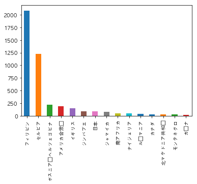

```python
## Distribution of countries teachers are from
print("Totally there are {} teachers.".format(teachers2.shape[0]))
teachers2.country.value_counts(ascending=False)[:15].plot(kind="bar")
print("These 15 counteries account for {}% of all teachers' nationality.".format(teachers.country.value_counts(ascending=False)[:15].sum()/teachers.shape[0]*100))
```

## (2)Distribution of regions teachers are from

Based on the result of (1), the region distribution does not mean much more than (1). Th most of Asian teachers are from Philippines and most of European teachers are from Serbia.

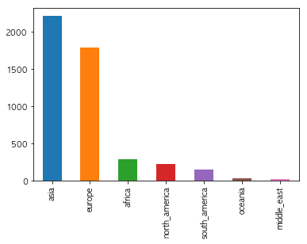

```python
## Distribution of regions teachers are from
teachers2.region.value_counts(ascending=False)[:15].plot(kind="bar")
```

## (3)Distribution of age of teachers

The graph below shows that the age of teachers has a long-tailed distribution on the high end. The peak of distribution is around 30. I noticed that there are some teachers whose ages are 0. I checked the official web site and confirmed that age columns of these teachers are really 0.

What I have found is that these teachers are all new teachers whose experiences are less than a year. I assume that DMM Eikaiwa changed the system and that it allowed teachers not to show their age. I assume that somehow these teachers' ages are displayed as 0, meaning NULL value.

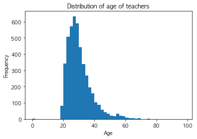

```python
plt.title("Distribution of age of teachers")
plt.xlabel("Age")
plt.rcParams["font.size"] = 15
teachers2.age.plot(kind="hist", bins=np.arange(0,100,2));
```

```python
teachers2[teachers2.age < 10]
```

|  | id | name | country | age | male | school | hobby | movie | fav | evalu | n_evalu | rate5 | rate4 | rate3 | rate2 | rate1 | message | staff_comment | 日本人講師 | ビジネス英会話 | キッズ向け | TOEFL対応 | 初心者向け | 上級者向け | スピーキングテスト対応 | Let'sGo対応 | 英検®対応 | IELTS | ネイティブ講師 | … |
| --- | --- | --- | --- | --- | --- | --- | --- | --- | --- | --- | --- | --- | --- | --- | --- | --- | --- | --- | --- | --- | --- | --- | --- | --- | --- | --- | --- | --- | --- | --- |
| 157 | 27580 | Kyan（キアン） | フィリピン | 0.0 | 1 | Saint John Bosco Institute of Arts and Sciences | ['Reading Books'] | ['The Story of Jonah'] | 52 | 4.94 | 147 | 139.0 | 6.0 | 1.0 | 1.0 | 0.0 | I'm a volunteer teacher and teaching is my pas... | 私はボランティア講師として務めていて、指導に情熱を抱いています。様々な年代や学習能力の人々に... | 0 | 0 | 0 | 0 | 0 | 0 | 0 | 0 | 0 | 0 | 0 | … |
| 3247 | 27555 | Princess Deborah Grace（プリンセス・デボラ・グレース） | フィリピン | 0.0 | 0 | Aces Tagum College | ['Karaoke Singing', ' Making Desserts', ' ukay... | ['Hacksaw Ridge'] | 126 | 4.88 | 328 | 291.0 | 33.0 | 3.0 | 0.0 | 1.0 | I graduated Bachelor of Science in Information... | 私は大学で情報技術を学びました。大学時代に様々な学内活動を主催して、自信をつけることができま... | 0 | 0 | 0 | 0 | 0 | 0 | 0 | 0 | 0 | 0 | 0 | … |
| 3578 | 26444 | Annex（アンネクス） | フィリピン | 0.0 | 0 | Xavier University - Ateneo de Cagayan | ['watching anime', ' doodle art', ' singing an... | ['Mean Girls'] | 28 | 4.76 | 104 | 86.0 | 12.0 | 6.0 | 0.0 | 0.0 | Hi! I am Annex, a Filipino who loves exploring... | こんにちは！私はアンネクスと言い、様々な文化に触れるのが大好きなフィリピン人です。私は生徒さ... | 0 | 0 | 0 | 0 | 0 | 1 | 0 | 0 | 0 | 0 | 0 | … |

```python
# remove teachers whose ages are 0
teachers2 = teachers2[teachers2.age > 10]
```

```
18.0 74.0
```

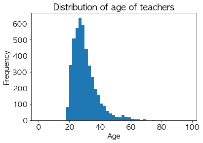

```python
plt.title("Distribution of age of teachers")
plt.xlabel("Age")
plt.rcParams["font.size"] = 15
teachers2.age.plot(kind="hist", bins=np.arange(0,100,2));
print(teachers2.age.min(), teachers2.age.max())
```

### (4)Distribution of gender of teachers

This is not a difficult problem. I can find the answer of the output of the cell "teachers.describe()", and it said that around 29% of all teachers are male.

Since some teachers were removed from the data, I visualize it again. Orange represents male teachers.

```
The proportion of male teachers are 29.538528515454942%
```

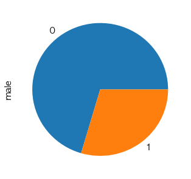

```python
plt.figure(figsize=(5,5))
print("The proportion of male teachers are {}%".format(teachers2.male.mean()* 100))
teachers2.male.value_counts().plot("pie");
```

### (5)Distribution of number of students who liked that teacher as "favorite"

```
23 10152
```

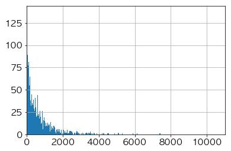

```python
# Distribution of fav counts of teachers
print(teachers2[teachers2.fav == 0].shape[0], teachers.fav.max())

plt.xlim(0,11000)
teachers2.fav.hist(bins= 1000)
```

### (6)Distribution of average evaluation score from students for each of teachers

The distribution of the teachers evaluation is below. As is shown, most of teachers' average scores are over 4, and it has a peak at around 4.9.

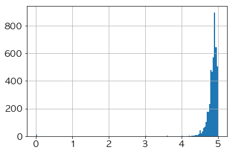

```python
teachers2.evalu.hist(bins=150);
```

### (7)Distribution of count of reviews from students for each of teachers

```python
teachers2.n_evalu = ["-1" if v is None else v for v in teachers2.n_evalu]
```

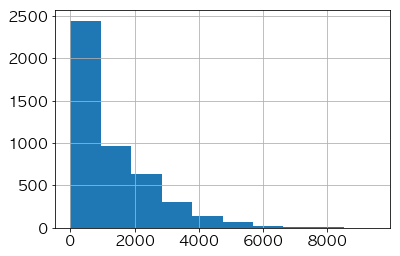

```python
teachers2.n_evalu = teachers2.n_evalu.astype("int")
teachers2.n_evalu.hist()
```

### (7)Distribution of evaluation score for each lesson.

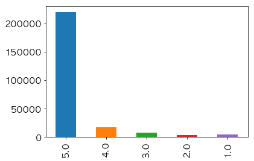

```python
reviews.rating.value_counts().sort_index(ascending=False).plot("bar")
```

### (8)Distribution of experience years of teachers.

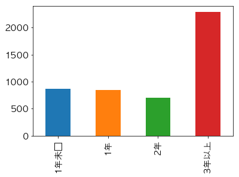

```python
teachers[["1年未満", "1年", "2年", "3年以上"]].sum().plot("bar")
```

```python
def get_years(row):
    for c in ["1年未満", "1年", "2年", "3年以上"]:
        if row[c]==1:
            if c == "1年未満":
                return "less than a year"
            if c == "1年":
                return "1 to 2 years"
            if c == "2年":
                return "2 to 3 years"
            if c == "3年以上":
                return "more than 3 years"

teachers2["years"] = teachers2.apply(get_years, axis=1)
```

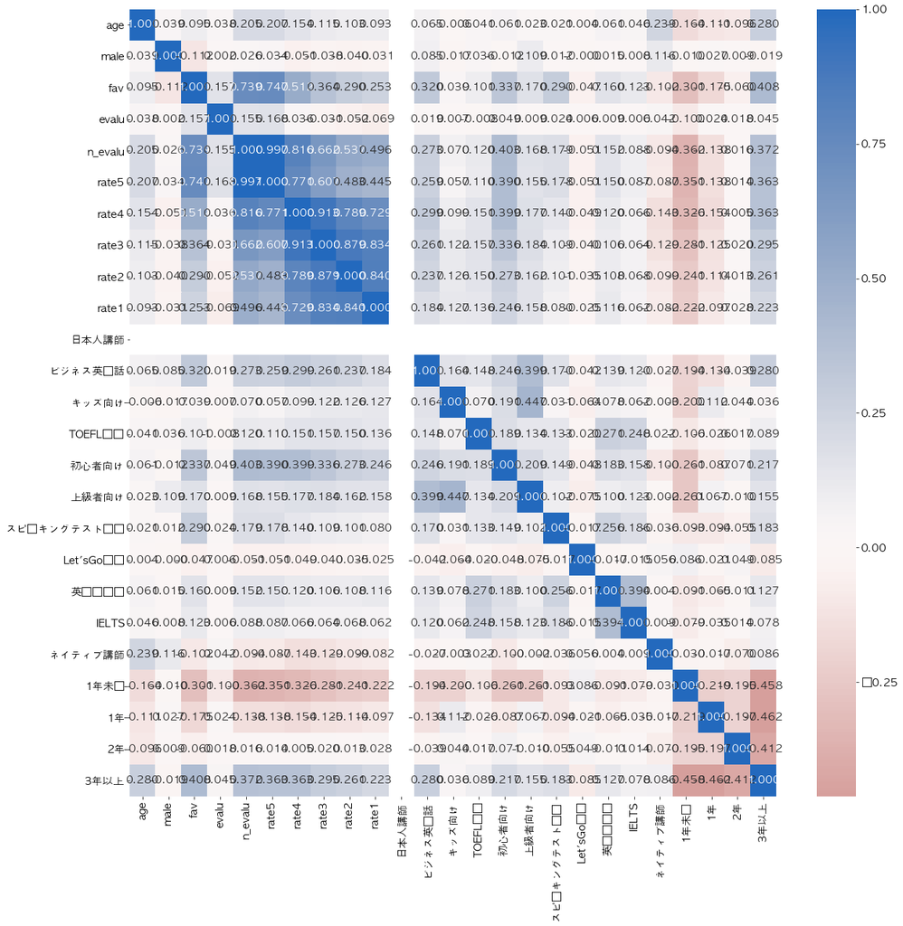

```python
numeric_vars = ["age","male","school","hobby","movie","fav","evalu","n_evalu","rate5","rate4","rate3","rate2","rate1","日本人講師","ビジネス英会話","キッズ向け","TOEFL対応","初心者向け","上級者向け","スピーキングテスト対応","Let'sGo対応","英検®対応","IELTS","ネイティブ講師","region","1年未満","1年","2年","3年以上"]

# correlation plot
plt.figure(figsize=[20,20])
sns.heatmap(teachers2[numeric_vars].corr(), annot=True, fmt=".3f", cmap="vlag_r", center=0);
```

```python
"""
# plot matrix : sample 1000 flight data so that plots are clearer and they render faster
samples = np.random.choice(teachers2.shape[0], 500, replace=False)
df2_sample = teachers2.iloc[samples,:]

g = sns.PairGrid(data=teachers2, vars=numeric_vars)
#g = g.map_diag(plt.hist, bins = 30);
g.map(plt.scatter);
"""
```

```
'\n# plot matrix : sample 1000 flight data so that plots are clearer and they render faster\nsamples = np.random.choice(teachers2.shape[0], 500, replace=False)\ndf2_sample = teachers2.iloc[samples,:]\n\ng = sns.PairGrid(data=teachers2, vars=numeric_vars)\n#g = g.map_diag(plt.hist, bins = 30);\ng.map…
```

# Bivariate Exploration

In this section, I will explore the bivariate exploration of teacher attributes.

## (Dead End) Q. Are the teachers who teach more lessons more evaluated than those who teach less lessons?

The most important and only variables which represents the students evaluation to the lessons is "review score" and "fav count". I will use "fav count" to measure the ability of teachers since univariate-(6) showed that almost all reviews had 5 point ratings, and it means that it would work only to distinguish "bad" teachers.

The variable to evaluate the number of lessons teachers has taught is "n_evalu"("number of all reviews the teacher has got so far"). However, before using this variable as a matrix, I have to confirm the hypothesis below.

## Since Fav count improves as teacher takes more lessons. So it is not a good matrix to evaluate "good" teachers.

## Q. Relationship between age and favorite count

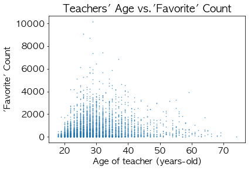

```python
plt.title("Teachers' Age vs.'Favorite' Count")
plt.xlabel("Age of teacher (years-old)")
plt.ylabel("'Favorite' Count")
plt.scatter(teachers2.age, teachers2.fav, s= 0.2)
```

```python
# create a column which representes age level of a teacher

def age_level(each_age):
    #for each_age in s:
        list = []
        if each_age < 30:
            return "younger than 30"
        elif each_age < 50:
            return "30 to 50 years old"
        else:
            return "older than 50"

teachers2["age_level"] = teachers.age.apply(age_level)
```

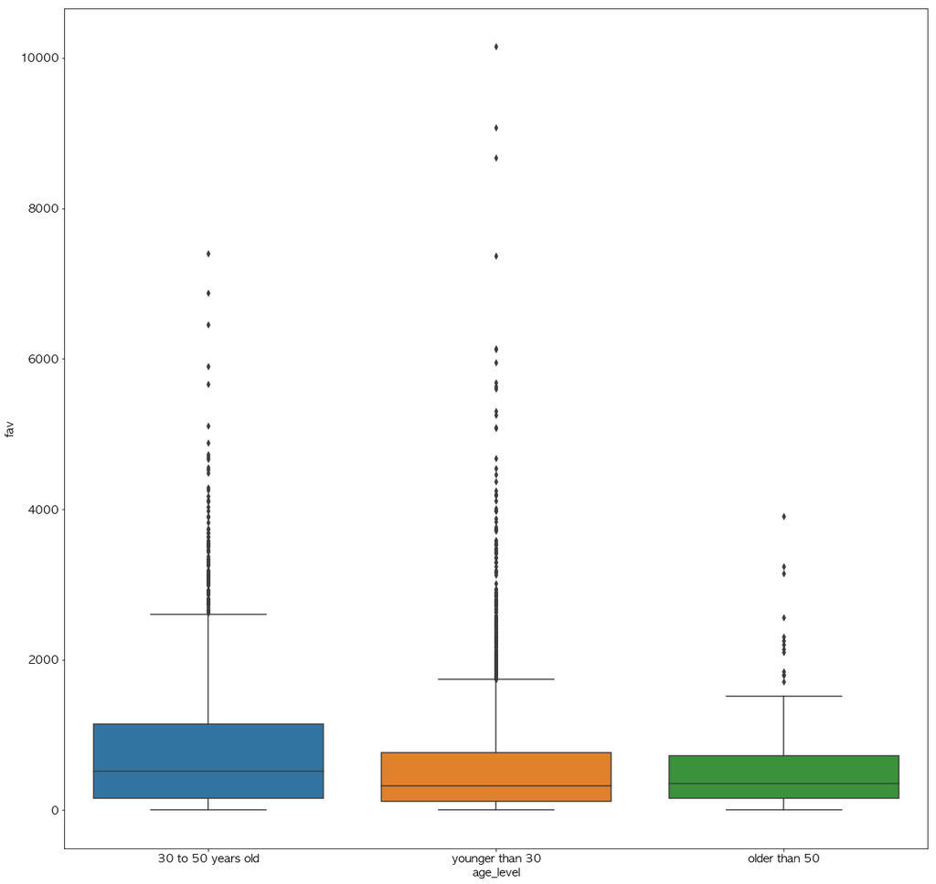

```python
plt.figure(figsize=(20,20))
sns.boxplot(x=teachers2.age_level, y=teachers2.fav)
```

## Visualization above does not account for the duration each teacher has been working.

#### 'Favorite' count is strongly related with working length.

```python
teachers3 = teachers2.copy()

bin_edges = np.arange(10,90,20)
teachers3["age_blocked"] = pd.cut(teachers3.age, bin_edges, right=False, include_lowest=True)

bin_edges = np.arange(0,800,200)
teachers3["n_eval_blocked"] = pd.cut(teachers3.n_evalu, bin_edges, right=False, include_lowest=True)


young = teachers2[teachers2.age < 30]
middle = teachers2[(30 <= teachers2.age) & (teachers2.age < 50)]
old = teachers2[(50 <= teachers2.age)]
```

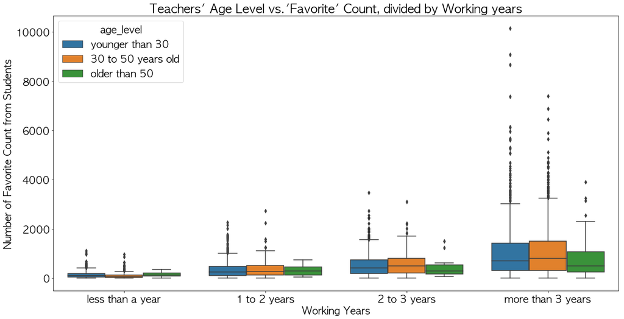

```python
plt.figure(figsize=(20,10))
order1=["younger than 30", "30 to 50 years old", "older than 50"]
order2=["less than a year", "1 to 2 years", "2 to 3 years", "more than 3 years"]

plt.rcParams["font.size"] = 20
sns.boxplot(data=teachers3, hue="age_level", y="fav", x="years", hue_order=order1, order=order2)


plt.title("Teachers' Age Level vs.'Favorite' Count, divided by Working years" )
plt.xlabel("Working Years")
plt.ylabel("Number of Favorite Count from Students");
```

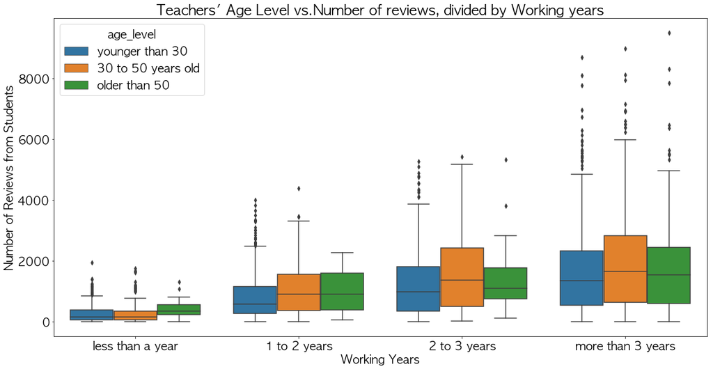

```python
plt.figure(figsize=(20,10))
order1=["younger than 30", "30 to 50 years old", "older than 50"]
order2=["less than a year", "1 to 2 years", "2 to 3 years", "more than 3 years"]

plt.rcParams["font.size"] = 20
sns.boxplot(data=teachers3, hue="age_level", y="n_evalu", x="years", hue_order=order1, order=order2)

plt.title("Teachers' Age Level vs.Number of reviews, divided by Working years" )
plt.xlabel("Working Years")
plt.ylabel("Number of Reviews from Students");
```

# Ignore cells below.

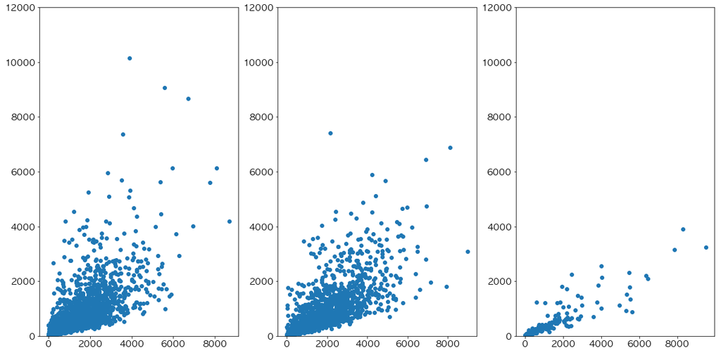

```python
plt.figure(figsize=(20,10))
plt.subplot(1,3,1)
plt.ylim(0,12000)
plt.scatter(young.n_evalu, young.fav)
plt.subplot(1,3,2)
plt.ylim(0,12000)
plt.scatter(middle.n_evalu, middle.fav)
plt.subplot(1,3,3)
plt.ylim(0,12000)
plt.scatter(old.n_evalu, old.fav)
```

## (Dead End) Q. What can be said about teachers who get more "fav"s?

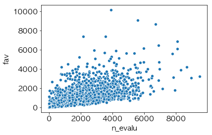

```python
### Whether student posts review or not does not rely on whether the lesson was good or bad ??????

sns.scatterplot(teachers2.n_evalu, teachers2.fav)
```

```python
reviews.date.min()
```

```
'2013-02-19 00:00:00'
```

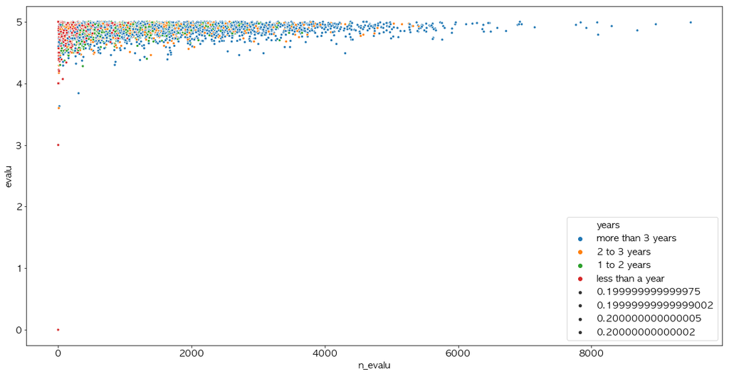

```python
plt.figure(figsize=(20,10))
sns.scatterplot(teachers2.n_evalu, teachers2.evalu, hue=teachers2.years, size=0.2)
```

```python
ttt = teachers2[teachers2["3年以上"] == 0]
```

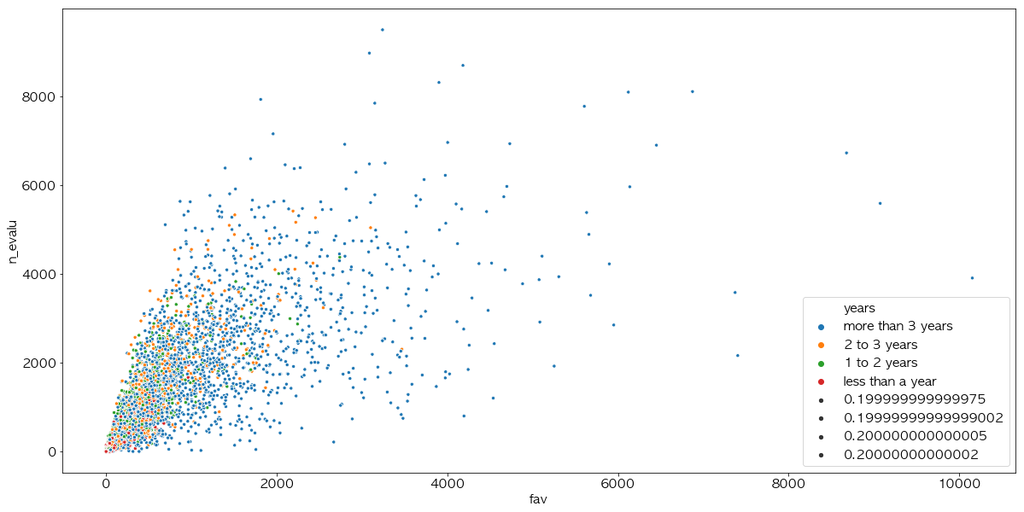

```python
plt.figure(figsize=(20,10))
sns.scatterplot(teachers2.fav, teachers2.n_evalu, hue=teachers2.years, size=0.2)
```

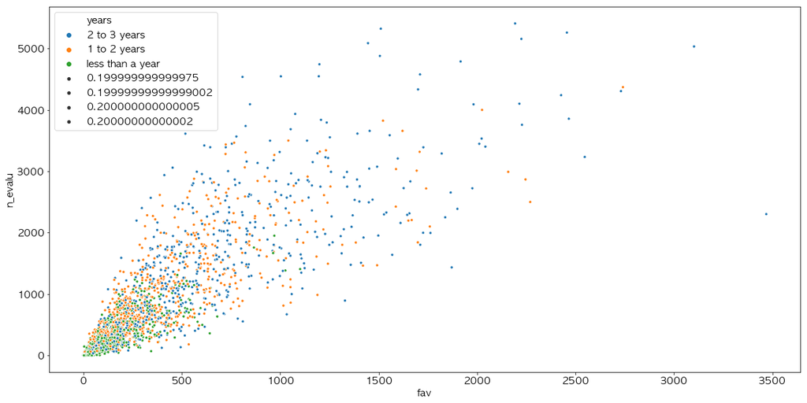

```python
plt.figure(figsize=(20,10))
sns.scatterplot(ttt.fav, ttt.n_evalu, hue=ttt.years, size=0.2)
```

```python
low_t = teachers2[(1000 < teachers2.n_evalu) & (teachers2.n_evalu < 2000)]
mid_t = teachers2[(2000 < teachers2.n_evalu) & (teachers2.n_evalu < 3000)]
mmm_t = teachers2[(3000 < teachers2.n_evalu) & (teachers2.n_evalu < 4000)]
high_t = teachers2[(4000 < teachers2.n_evalu) & (teachers2.n_evalu < 5000)]
```

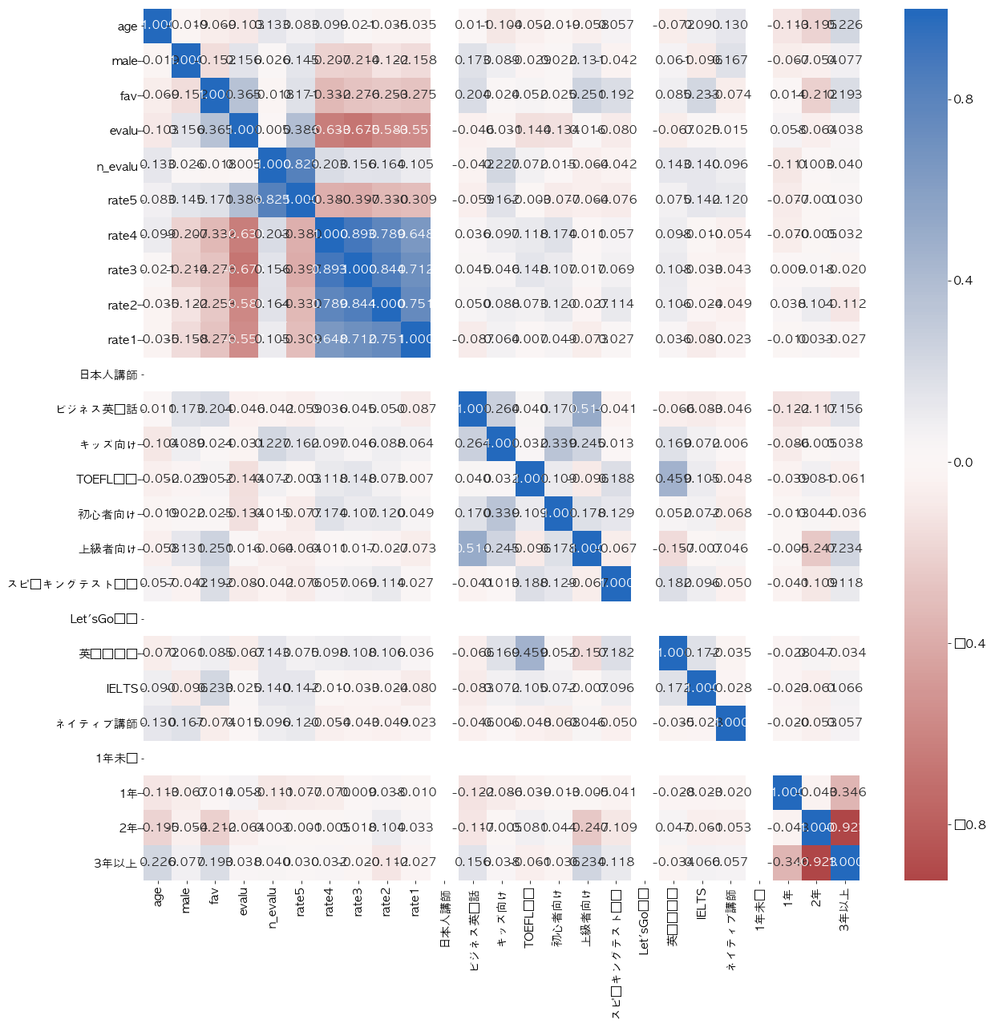

```python
plt.figure(figsize=[20,20])
sns.heatmap(high_t[numeric_vars].corr(), annot=True, fmt=".3f", cmap="vlag_r", center=0);
```

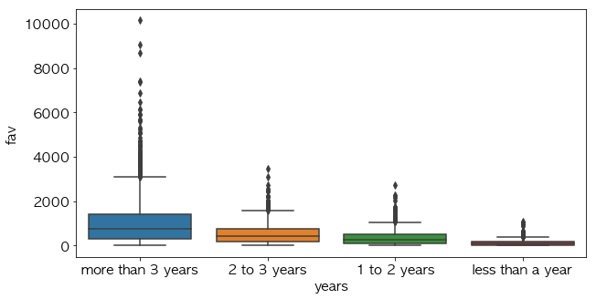

```python
plt.figure(figsize=(10,5))
sns.boxplot(teachers2.years, teachers2.fav)
```

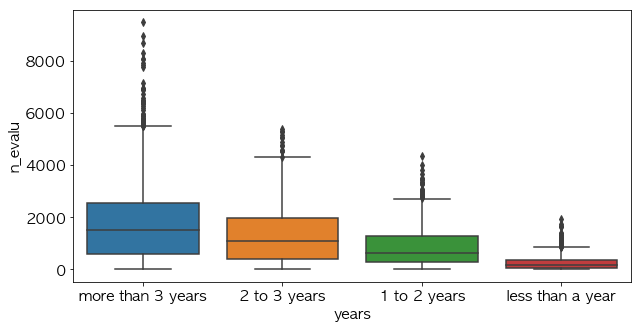

```python
plt.figure(figsize=(10,5))
sns.boxplot(teachers2.years, teachers2.n_evalu)
```

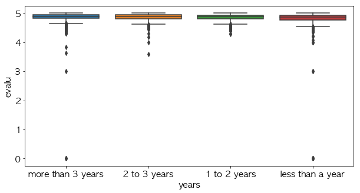

```python
plt.figure(figsize=(10,5))
sns.boxplot(teachers2.years, teachers2.evalu)
```

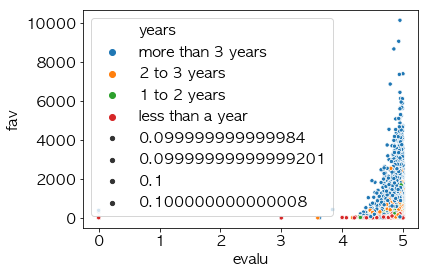

```python
sns.scatterplot(teachers2.evalu, teachers2.fav, hue=teachers2.years, size=0.1)
```